# Visualización

Grupo G3 - Los panteras

2020-05-30

Para este proyecto hemos utilizado el dataset oficial dado por la Junta de Andalucía:

https://www.juntadeandalucia.es/institutodeestadisticaycartografia/badea/operaciones/consulta/anual/39409?CodOper=b3_2314&codConsulta=39409

Todo el análisis se ha realizado de manera autónoma (sin basarnos en ningún rmarkdown ya existente) y basándonos en lo explicado en clase y en diversas páginas de internet.

# Procesamiento de los datos

```r
library(dplyr)
library(ggplot2)
library(ggridges)
library(ggpubr)

covid_datos <- read.csv("Datasets/covid_datos.txt", sep=";", encoding = "UTF-8")

# Se genera una ultima columna al finalizar cada linea con ';' por lo que la eliminamos
covid_datos <- covid_datos[, 1:4]

# Para evitar problemas con los acentos en las columnas cambiamos el nombre de la primera
names(covid_datos)[1] <- "Fecha"

covid_datos$Fecha <- as.Date(covid_datos$Fecha, format='%d/%m/%Y')

# Los valores NA los convertimos a 0
indices <- which(is.na(covid_datos$Valor))
covid_datos$Valor[indices] = 0
```

# Información del dataset

Nuestro dataset, una vez hecho el preprocesamiento, tiene las siguientes columnas:

```r
names(covid_datos)
```

```
## [1] "Fecha"      "Territorio" "Medida"     "Valor"
```

```r
levels(covid_datos$Territorio)
```

```
## [1] "Almería"   "Andalucía" "Cádiz"     "Córdoba"   "Granada"   "Huelva"
## [7] "Jaén"      "Málaga"    "Sevilla"
```

- Medida: Campo de tipo factor, contemplando las siguientes medidas:

```r
levels(covid_datos$Medida)
```

```
## [1] "Confirmados PCR"              "Curados"
## [3] "Defunciones"                  "Hospitalizados"
## [5] "Total confirmados (PCR+test)" "UCI"
```

- Valor: Campo de tipo ‘numeric’, que devuelve el valor de cada una de las medidas anteriormente expuestas.

# Gráficas

Una vez hecho el preprocesamiento y descrito nuestro dataset, exponemos unas gráficas representativas acerca de la situación del covid-19 en Andalucía y todas sus provincias.

1. Total de confirmados por día, incluyendo los positivos en PCR y los de tests, en toda la comunidad autónoma de Andalucía.

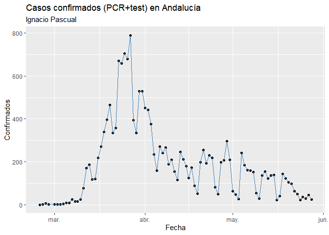

```r
confAndalucia <- covid_datos %>%
  filter(Medida == "Total confirmados (PCR+test)" & Territorio == "Andalucía") %>%
  arrange(Fecha)

confirmados <- ggplot(confAndalucia, aes(x=Fecha, y=Valor)) +
  geom_point() +
  labs(subtitle="Ignacio Pascual") +
  geom_line(color='steelblue') +
  labs(title="Casos confirmados (PCR+test) en Andalucía",
         y = "Confirmados",
         x = "Fecha")

confirmados
```

Otra forma de representar estos datos sería con la función stat_density2d(), gracias a la cual podemos observar más fácilmente donde se concentran la mayoría de puntos.

[figure not shown]

```r
maxI <-  30 + max(confAndalucia$Valor)

ggplot(confAndalucia, aes(Fecha, Valor)) +
  ylim(min = -20, max = maxI) +
  stat_density2d(geom="tile", aes(fill = ..density..), contour = FALSE) +
  geom_point(colour = "white") +
  labs(title = "Defunciones en Andalucía", subtitle="Ignacio Pascual")
```

2. Utilizando la gráfica anterior, llamada confAndalucia, utilizamos la función cumsum() en el eje y para ver el número de casos totales en Andalucía.

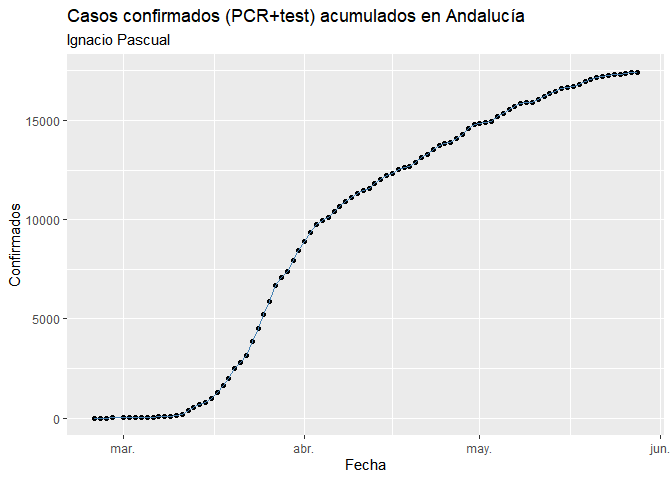

```r
ggplot(confAndalucia, aes(x=Fecha, y=cumsum(Valor))) +
  geom_point() +
  geom_line(color='steelblue') +
  labs(title="Casos confirmados (PCR+test) acumulados en Andalucía",
       subtitle = "Ignacio Pascual",
         y = "Confirmados",
         x = "Fecha")
```

Podemos observar que desde mediados de marzo hasta princios de abril, la línea de puntos crece mucho más rápido. Posteriormente, y tras unas semanas de confinamiento podemos apreciar como la línea de puntos deja de ser tan vertical, indicando que sigue creciendo pero de forma más lenta.

3. Defunciones vs Curados en Andalucía.

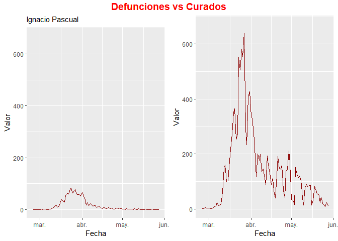

```r
# Extraemos el límite de ambas gráficas, que será el de máximo número de curados + 30.

ymax = 30 + max(covid_datos$Valor[covid_datos$Medida == "Curados"])

# Gráfica de número de defunciones

covid_defunciones <- covid_datos %>%
  filter(Medida == "Defunciones" & Territorio == "Andalucía")

p1 <- ggplot(covid_defunciones, aes(x=Fecha)) +
  ylim(min = 0, max = ymax) +
  geom_line(aes(y = Valor), color = "darkred")+
  labs(subtitle="Ignacio Pascual")

# Gráfica de número de curados

covid_curados <- covid_datos %>%
  filter(Medida == "Curados" & Territorio == "Andalucía")

p2 <- ggplot(covid_curados, aes(x=Fecha)) +
  ylim(min = 0, max = ymax) +
  geom_line(aes(y = Valor), color = "darkred")

figure <- ggarrange(p1,p2)
annotate_figure(figure, top = text_grob("Defunciones vs Curados",
               color = "red", face = "bold", size = 14))
```

A continuación, vamos a procesar los datos de manera que se representaran gráficas de Andalucía ordenadas por días y meses. Con esto, pretendemos visualizar los efectos del tiempo sobre la pandemia y como evoluciona esta por meses.

4. Gráficas Infectados en Andalucía por Covid-19 al día, separados en meses.

[figure not shown]

```r
TCFeb <- covid_datos[(format(covid_datos$Fecha, "%m") == '02') & covid_datos$Territorio == "Andalucía" & covid_datos$Medida == "Total confirmados (PCR+test)", ]

TCMarzo <- covid_datos[(format(covid_datos$Fecha, "%m") == '03') & covid_datos$Territorio == "Andalucía" & covid_datos$Medida == "Total confirmados (PCR+test)", ]

TCAbril <- covid_datos[(format(covid_datos$Fecha, "%m") == '04') & covid_datos$Territorio == "Andalucía" & covid_datos$Medida == "Total confirmados (PCR+test)", ]

TCMayo <- covid_datos[(format(covid_datos$Fecha, "%m") == '05') & covid_datos$Territorio == "Andalucía" & covid_datos$Medida == "Total confirmados (PCR+test)", ]

gf <- ggplot(TCFeb, aes(x=Fecha, y=Valor)) +
  geom_point() +
  geom_line(aes(group = 1)) +
  labs(title = "Confirmados Febrero",
       y = "Confirmados",
       x = "Fecha")+
  labs(subtitle="Juan Manuel Morales")

gm <- ggplot(TCMarzo, aes(x=Fecha, y=Valor)) +
  geom_point() +
  geom_line(aes(group = 1)) +
  labs(title = "Confirmados Marzo",
       y = "Confirmados",
       x = "Fecha")+
  labs(subtitle="Juan Manuel Morales")

ga <- ggplot(TCAbril, aes(x=Fecha, y=Valor)) +
  geom_point() +
  geom_line(aes(group = 1)) +
  labs(title = "Confirmados Abril",
       y = "Confirmados",
       x = "Fecha")+
  labs(subtitle="Juan Manuel Morales")

gm <- ggplot(TCMayo, aes(x=Fecha, y=Valor)) +
  geom_point() +
  geom_line(aes(group = 1)) +
  labs(title = "Confirmados Mayo",
       y = "Confirmados",
       x = "Fecha")+
  labs(subtitle="Juan Manuel Morales")

figure2 <- ggarrange(gf,gm,ga, gm)
annotate_figure(figure2, top = text_grob("Confirmados Feb, Mar, Abril, Mayo", face = "bold", size = 12))+
  labs(subtitle = "Juan Manuel Morales")
```

Podemos ver como a principios de la pandemia las gráficas tenían una tendencia positiva, donde el número de infectados crecía rápidamente por días. Sin embargo, en abril, ya se puede apreciar como algunos días el número de infectados es pequeño, creando así una gráfica llamada “de sierra”.

5. Confirmados totales por meses en Andalucía

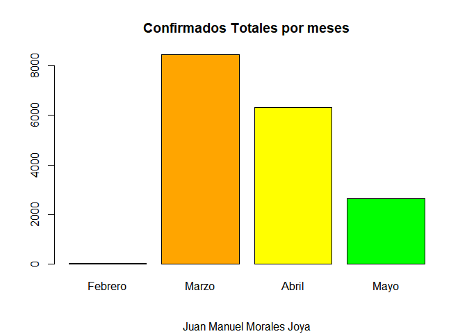

```r
# Números Totales Confirmados por Meses

sumF <- sum(TCFeb$Valor)

sumM <- sum(TCMarzo$Valor)

sumA <- sum(TCAbril$Valor)

sumMy <- sum(TCMayo$Valor)

vMeses <- c(Febrero = sumF, Marzo = sumM, Abril = sumA, Mayo = sumMy)

barplot(vMeses, col = c("red", "orange", "yellow", "green"), main = "Confirmados Totales por meses", sub = "Juan Manuel Morales Joya")
```

Ante los datos presentes, podemos comprobar que el mes de Marzo fue el mes con más infectados de esta pandemia.

6. Diferencias entre Hospitalizados Totales y los que están graves (UCI) por meses en Andalucía.

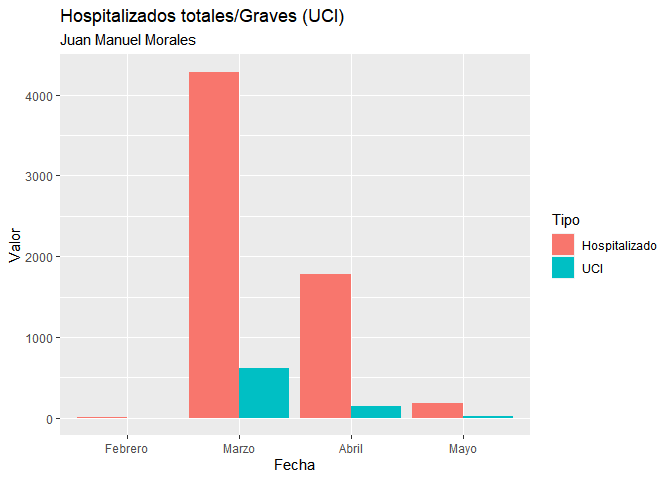

```r
hosAndF <- covid_datos[(format(covid_datos$Fecha, "%m") == '02') & covid_datos$Territorio == "Andalucía" & covid_datos$Medida == "Hospitalizados", ]

sumhaF <- sum(hosAndF$Valor)

UCIAndF <- covid_datos[(format(covid_datos$Fecha, "%m") == '02') & covid_datos$Territorio == "Andalucía" & covid_datos$Medida == "UCI", ]

sumUaF <- sum(UCIAndF$Valor)



hosAndM <- covid_datos[(format(covid_datos$Fecha, "%m") == '03') & covid_datos$Territorio == "Andalucía" & covid_datos$Medida == "Hospitalizados", ]

sumhaM <- sum(hosAndM$Valor)

UCIAndM <- covid_datos[(format(covid_datos$Fecha, "%m") == '03') & covid_datos$Territorio == "Andalucía" & covid_datos$Medida == "UCI", ]

sumUaM <- sum(UCIAndM$Valor)



hosAndA <- covid_datos[(format(covid_datos$Fecha, "%m") == '04') & covid_datos$Territorio == "Andalucía" & covid_datos$Medida == "Hospitalizados", ]

sumhaA <- sum(hosAndA$Valor)

UCIAndA <- covid_datos[(format(covid_datos$Fecha, "%m") == '04') & covid_datos$Territorio == "Andalucía" & covid_datos$Medida == "UCI", ]

sumUaA <- sum(UCIAndA$Valor)

hosAndMy <- covid_datos[(format(covid_datos$Fecha, "%m") == '05') & covid_datos$Territorio == "Andalucía" & covid_datos$Medida == "Hospitalizados", ]

sumhaMy <- sum(hosAndMy$Valor)

UCIAndMy <- covid_datos[(format(covid_datos$Fecha, "%m") == '05') & covid_datos$Territorio == "Andalucía" & covid_datos$Medida == "UCI", ]

sumUaMy <- sum(UCIAndMy$Valor)

dat <- data.frame(
  Fecha = factor(c("Febrero","Febrero", "Marzo", "Marzo", "Abril", "Abril", "Mayo", "Mayo"), levels = c("Febrero", "Marzo", "Abril", "Mayo")),
  Tipo = c("Hospitalizado", "UCI"),
  Valor = c(sumhaF,sumUaF,sumhaM, sumUaM, sumhaA, sumUaA, sumhaMy, sumUaMy)
)

ggplot() +
 geom_bar(data=dat,aes(x=Valor, y=Fecha,fill=Tipo), stat='identity', position='dodge') +
 coord_flip()+labs(title = "Hospitalizados totales/Graves (UCI)", subtitle = "Juan Manuel Morales")
```

## Por provincias

7. En esta gráfica de barras podemos ver los fallecidos por cada provincia y, además, Andalucía.

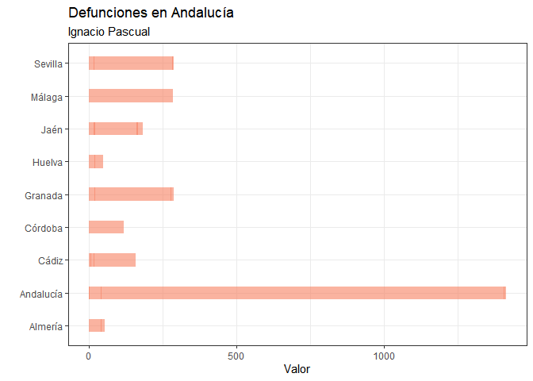

```r
covid_datos[covid_datos$Medida == "Defunciones", ] %>%
  ggplot( aes(x=Territorio, y=Valor)) +
    geom_bar(stat="identity", fill="#f68060", alpha=.6, width=.4) +
    coord_flip() +
    xlab("") +
    theme_bw() +
    labs(title = "Defunciones en Andalucía", subtitle="Ignacio Pascual")
```

8. Comparativa positivos por provincia.

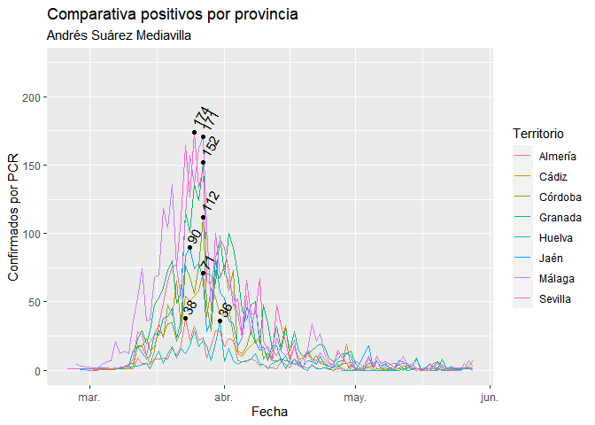

```r
# Selecciono los datos que voy a representar
confirmadosPCR <- filter(covid_datos, Medida == "Confirmados PCR", Territorio != "Andalucía")

# Almaceno los valores maximos alcanzados agrupados por territorios hacieno uso de las funciones del paquete DPLYR
maximos <- confirmadosPCR %>% group_by(Territorio) %>%
  filter(Valor == max(Valor))

## Primer tipo de representación
# Grafico de todas las provincias con valores maximos marcados
# Añado un margen extra en el limite del eje Y para que la representacion se vea clara
g1 <- ggplot(confirmadosPCR, aes(x = Fecha, y = Valor)) +
  ylim(min = 0, max = max(maximos$Valor+50)) +
  geom_line(aes(color = Territorio)) +
  geom_point(data = maximos) +
  geom_text(maximos, mapping = aes(label = Valor), hjust =-0.3, vjust = 0.3, angle = 60) +
  ylab("Confirmados por PCR") +
  labs(subtitle="Andrés Suárez Mediavilla") +
  ggtitle("Comparativa positivos por provincia")
g1
```

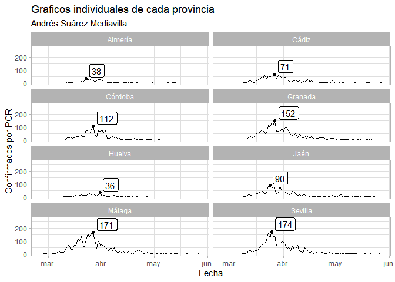

```r
# Grid con los graficos individuales de provincias
g2 <- ggplot(confirmadosPCR, aes(x = Fecha, y = Valor)) +
  geom_line() +
  ylim(min = 0, max = max(maximos$Valor+100)) +
  ylab("Confirmados por PCR") +
  facet_wrap(~Territorio, ncol = 2) +
  geom_point(data = maximos) +
  geom_label(maximos, mapping = aes(label = Valor), hjust = -0.2, vjust = -0.1) +
  theme_light() +
  labs(subtitle="Andrés Suárez Mediavilla") +
  ggtitle("Graficos individuales de cada provincia")
g2
```

9. Gráfico comparativo infectados + curados y trazado de la media.

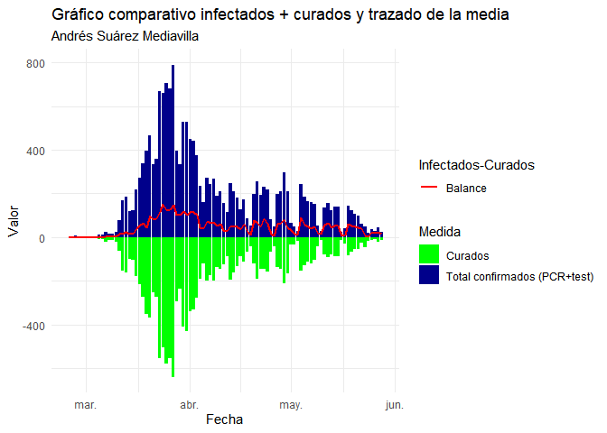

```r
## Segundo tipo
# Representacion del total de infectados y el total de curados en Andalucia

curados_confirmados_PCR_Test <- covid_datos %>%
  filter(Medida == "Total confirmados (PCR+test)" | Medida == "Curados", Territorio == "Andalucía") %>%
  arrange(Fecha) # Ordenado desde el primer positivo hasta el dia de hoy

# Invierto el valor de los curados para mostrar el contraste en la grafica
indices <- which(curados_confirmados_PCR_Test$Medida == "Curados")
curados_confirmados_PCR_Test[indices, "Valor"] <- -curados_confirmados_PCR_Test[indices, "Valor"]

medias <- curados_confirmados_PCR_Test$Valor[c(TRUE, FALSE)]+
  curados_confirmados_PCR_Test$Valor[c(FALSE, TRUE)]

mediaDia <- covid_datos %>% select(Fecha) %>%
  arrange(Fecha) %>%
  unique %>%
  mutate(medias)

# El grafico esta compuesto de dos barras, una indicando los infectados, y otra barra invertida indicando los curados de ese dia. Así mismo, se muestra el trazado del balance infectados-curados, haciendo la diferencia entre las variables para cada dia

g3 <- ggplot(curados_confirmados_PCR_Test, aes(x = Fecha, y = Valor))+
  geom_bar(aes(fill = Medida),stat = "identity") +
  geom_line(mediaDia, mapping = aes(x = Fecha, y = medias, color = "red"), size = 1) +
  scale_fill_manual(values = c("green", "darkblue")) +
  theme_minimal()+
  scale_color_manual(name = "Infectados-Curados", values = "red", label = "Balance")+
  labs(subtitle="Andrés Suárez Mediavilla") +
  ggtitle("Gráfico comparativo infectados + curados y trazado de la media")
g3
```

10. Porcentaje distribución de infectados por provincias.

[figure not shown]

```r
# Otro grafico viendo el porcentaje acumulado por provincia
# Incidencias acumuladas
confirmados_PCR_Test <- covid_datos %>%
  filter(Medida == "Total confirmados (PCR+test)", Territorio != "Andalucía") %>%
  arrange(Fecha)

# Calculo la suma total de casos por provincia
malaga <- confirmados_PCR_Test %>%
  filter(Territorio == "Málaga") %>%
  select(Valor) %>%
  sum()

sevilla <- confirmados_PCR_Test %>%
  filter(Territorio == "Sevilla") %>%
  select(Valor) %>%
  sum()

granada <- confirmados_PCR_Test %>%
  filter(Territorio == "Granada") %>%
  select(Valor) %>%
  sum()

cordoba <- confirmados_PCR_Test %>%
  filter(Territorio == "Córdoba") %>%
  select(Valor) %>%
  sum()

cadiz <- confirmados_PCR_Test %>%
  filter(Territorio == "Cádiz") %>%
  select(Valor) %>%
  sum()

huelva <- confirmados_PCR_Test %>%
  filter(Territorio == "Huelva") %>%
  select(Valor) %>%
  sum()

almeria <- confirmados_PCR_Test %>%
  filter(Territorio == "Almería") %>%
  select(Valor) %>%
  sum()

jaen <- confirmados_PCR_Test %>%
  filter(Territorio == "Jaén") %>%
  select(Valor) %>%
  sum()

# Calculo el total de casos
total <- sum(malaga, jaen, sevilla, cordoba, granada, cadiz, almeria, huelva)

# A partir de aqui, creo un data frame con los datos necesarios para poder representar un grafico en forma de tarta
territorios <- covid_datos %>% filter(Territorio != "Andalucía") %>%
  select(Territorio) %>%
  unique()

p <- function(num, t){
  return(round(num/t*100, 2))
}

df <- data.frame(territorios[1], Acumulado = c(almeria,cadiz, cordoba, granada, huelva, jaen, malaga, sevilla), Porcentaje = c(p(almeria, total),p(cadiz, total),p(cordoba, total),p(granada, total),p(huelva, total),p(jaen, total),p(malaga, total),p(sevilla, total)))

# Colores a usar en el grafico
colores <- c("#999999", "#E69F00", "#56B4E9", "#009E73",
          "#F0E442", "#0072B2", "#D55E00", "#CC79A7")

## Grafico de tarta
# Este grafico es una combinacion de un stacked bar chart y coordenadas polares.
# los parametros de la funcion coord_polar son theta y start, theta sirve para situar el eje de mapeo de angulos, y el start se corresponde con el desplazamiento que queramos realizar en el punto incial en radiades.
g4 <- ggplot(df, aes(x = "", y = Porcentaje, fill = Territorio)) +
  geom_bar(width = 1, stat = "identity", color = "white") +
  coord_polar("y", start = 0)+
  scale_fill_manual(values = colores) +
  theme_void()+
  geom_text(aes(label = Porcentaje), position = position_stack(vjust = 0.5))+
  labs(subtitle="Andrés Suárez Mediavilla") +
  ggtitle("Porcentaje distribución de infectados en Andalucía")
g4
```